# Diabetic Retinopathy Detection

1. Rudolph Almeida
2. Niral Almeida
3. Melissa D'Cunha

## What is Diabetic Retinopathy?

1. Diabetic retinopathy is the leading cause of blindness in the working-age population of the developed world. It is estimated to affect over 93 million people.
2. Diabetic Retinopathy (DR) is an eye disease associated with long-standing diabetes.
3. Progression to vision impairment can be slowed or averted if DR is detected in time, however this can be difficult as the disease often shows few symptoms until it is too late to provide effective treatment.
4. Currently, detecting DR is a time-consuming and manual process that requires a trained clinician to examine and evaluate digital color fundus photographs of the retina. By the time human readers submit their reviews, often a day or two later, the delayed results lead to lost follow up, miscommunication, and delayed treatment.

## Our Solution

1. Our project aims to build a comprehensive and automated system which expects a color fundus photograph as input and returns a rating based on how severe the spread of DR is in that particular eye.
2. The system generates a value between 0-4 for each image, where 0 represents NO DR and 4 represents proliferative DR.

# The Dataset

## Data Description

The dataset was obtained from a competition hosted on [Kaggle](https://www.kaggle.com/c/diabetic-retinopathy-detection). The images in the dataset is a large collection of high-resolution retina images taken under a wide variety of imaging conditions. Each subject provides two images, one for the left eye and one for the right. Images are named in the following convention: `<subjectID>_<left|right>.jpeg`(1_left.jpeg is the left eye of subject 1).

A clinician has rated the presence of diabetic retinopathy in these images on a scale of 0-4 according the following scale:

0 - No DR

1 - Mild

2 - Moderate

3 - Severe

4 - Proliferative DR

The images in the dataset come from a wide variety of models and type of cameras, which can affect the apperance of left vs. right. Some images are shown as one would see the retina anatomically(macula on the left, optic nerve on the right for the right eye). Others are shown as one would see them through a microscope condensing lens (i.e. inverted, as one sees in a typical eye exam). There are two ways to tell if an image in inverted:

- It is inverted if the macula(the small dark central area) is slightly higher than the midline through the optic nerve. If the macula is lower than the midline of the optic nerve, it's not inverted.
- If there is a notch on the side of the image then it's not inverted. If there is no notch then it is inverted.

## Dataset Size and Distribution

```python
print('Dataset size: {}'.format(len(data)))
```

```
Dataset size: 35125
```

```
array([[<matplotlib.axes._subplots.AxesSubplot object at 0x7f37c93a8e80>]],
      dtype=object)
```

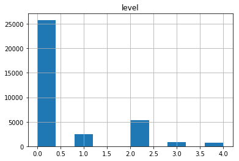

```python
data.hist(column='level')
```

## Percentages of each level in the data

```python
for i in range(5):
    print('% of {} => {}'.format(i, round(percentage_of(data, i), 2)))
```

```
% of 0 => 73.48
% of 1 => 6.96
% of 2 => 15.07
% of 3 => 2.49
% of 4 => 2.02
```

## Rating Examples

```python
rating_0.head(10)
```

|  | image | level |
| --- | --- | --- |
| 0 | 10_left | 0 |
| 1 | 10_right | 0 |
| 2 | 13_left | 0 |
| 3 | 13_right | 0 |
| 8 | 17_left | 0 |
| 10 | 19_left | 0 |
| 11 | 19_right | 0 |
| 12 | 20_left | 0 |
| 13 | 20_right | 0 |
| 14 | 21_left | 0 |

```python
rating_1.head(10)
```

|  | image | level |
| --- | --- | --- |
| 4 | 15_left | 1 |
| 9 | 17_right | 1 |
| 22 | 30_left | 1 |
| 28 | 36_left | 1 |
| 102 | 114_left | 1 |
| 103 | 114_right | 1 |
| 150 | 178_left | 1 |
| 151 | 178_right | 1 |
| 173 | 204_right | 1 |
| 180 | 214_left | 1 |

```python
rating_2.head(10)
```

|  | image | level |
| --- | --- | --- |
| 5 | 15_right | 2 |
| 23 | 30_right | 2 |
| 30 | 40_left | 2 |
| 42 | 51_left | 2 |
| 46 | 54_left | 2 |
| 47 | 54_right | 2 |
| 78 | 78_left | 2 |
| 79 | 78_right | 2 |
| 80 | 79_left | 2 |
| 81 | 79_right | 2 |

```python
rating_3.head(10)
```

|  | image | level |
| --- | --- | --- |
| 90 | 99_left | 3 |
| 91 | 99_right | 3 |
| 134 | 163_left | 3 |
| 135 | 163_right | 3 |
| 283 | 328_right | 3 |
| 300 | 352_left | 3 |
| 301 | 352_right | 3 |
| 335 | 391_right | 3 |
| 402 | 458_left | 3 |
| 440 | 509_left | 3 |

```python
rating_4.head(10)
```

|  | image | level |
| --- | --- | --- |
| 6 | 16_left | 4 |
| 7 | 16_right | 4 |
| 184 | 217_left | 4 |
| 185 | 217_right | 4 |
| 252 | 294_left | 4 |
| 253 | 294_right | 4 |
| 280 | 326_left | 4 |
| 281 | 326_right | 4 |
| 314 | 367_left | 4 |
| 315 | 367_right | 4 |

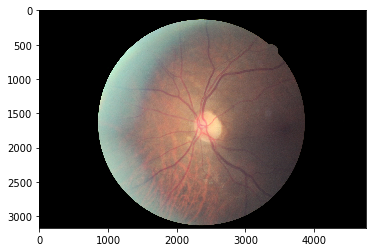

```python
img_rat0 = cv2.imread('../data/train/10_left.jpeg', cv2.IMREAD_UNCHANGED)
plt.imshow(img_rat0[:, :, ::-1])
```

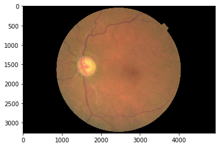

```python
img_rat1 = cv2.imread('../data/train/15_left.jpeg', cv2.IMREAD_UNCHANGED)
plt.imshow(img_rat1[:, :, ::-1])
```

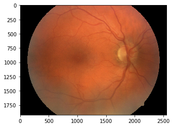

```python
img_rat2 = cv2.imread('../data/train/30_right.jpeg', cv2.IMREAD_UNCHANGED)
plt.imshow(img_rat2[:, :, ::-1])
```

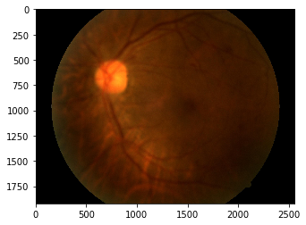

```python
img_rat3 = cv2.imread('../data/train/99_left.jpeg', cv2.IMREAD_UNCHANGED)
plt.imshow(img_rat3[:, :, ::-1])
```

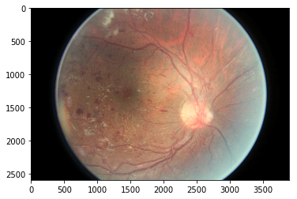

```python
img_rat4 = cv2.imread('../data/train/16_left.jpeg', cv2.IMREAD_UNCHANGED)
plt.imshow(img_rat4[:, :, ::-1])
```

# Preprocessing of dataset

As many different instruments or microscopes were used to obtain the retina images, the training images need to be preprocessed to create a consistent dataset. Images in the dataset and practical use come in a wide variety of dimensions, have noise and other artifacts, don't have good contrast and are not uniform. As neural networks and other learning algorithms expect images of similar nature, we need to create images of the same size.

#### Preprocessing Code

```
#!/bin/bash

# To run, this assumes that you are in the directory with the images
# unpacked into train/ and test/.  To run, it works best to use GNU
# parallel as
#
#   ls train/*.jpeg test/*.jpeg | parallel ./process.sh
#

# Size of the output image
size=512x512

in_file=$1
out_file=$1

com="convert $in_file \
-set colorspace HSL -channel lightness -equalize \
-set colorspace RGB -channel G -separate -depth 8 \
-convolve Gaussian \
-background black \
-fuzz 10% -trim +repage -resize $size \
-gravity center -background black -extent $size \
-resize $size \
processed/$out_file"

echo $com

$com
```

The techniques applied for image processing include:

1. Seperation of the green channel
2. Gaussian Filtering for noise removal
3. Trimming of the black space around the retina
4. Center the retina circle in the center of the image
5. Perfectly black background
6. Histogram equalization of the **light** channel in the HSL colorspace

Preprocessing of the images was done using ImageMagick which is a image processing tool for batch processing of images. It provides a command line interface to image processing which we used in the shell script above. Also we used GNU parallel to parallelize the processing of the images for faster processing.

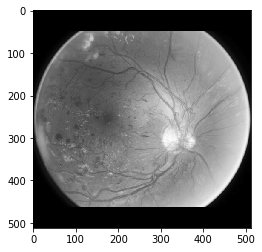

```python
processed_image = cv2.imread('./data/processed/16_left.jpeg', cv2.IMREAD_UNCHANGED)
plt.imshow(processed_image, cmap='gray')
```

# Feature Extraction and Dimensionality Reduction

## Histogram of Oriented Gradients

1. The histogram of oriented gradients (HOG) is a feature descriptor used in computer vision and image processing for the purpose of object detection. The technique counts occurrences of gradient orientation in localized portions of an image.
2. The essential thought behind the histogram of oriented gradients descriptor is that local object appearance and shape within an image can be described by the distribution of intensity gradients or edge directions.
3. The image is divided into small connected regions called cells, and for the pixels within each cell, a histogram of gradient directions is compiled. The descriptor is the concatenation of these histograms.

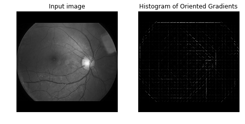

```python
image = io.imread('./data/processed/1002_left.jpeg')

fd, hog_image = hog(image, orientations=8, pixels_per_cell=(16, 16),
                    cells_per_block=(1, 1), visualise=True, block_norm='L1')

fig, (ax1, ax2) = plt.subplots(1, 2, figsize=(8, 4), sharex=True, sharey=True)

ax1.axis('off')
ax1.imshow(image, cmap=plt.cm.gray)
ax1.set_title('Input image')
ax1.set_adjustable('box-forced')

# Rescale histogram for better display
hog_image_rescaled = exposure.rescale_intensity(hog_image, in_range=(0, 10))

ax2.axis('off')
ax2.imshow(hog_image_rescaled, cmap=plt.cm.gray)
ax2.set_title('Histogram of Oriented Gradients')
ax1.set_adjustable('box-forced')
plt.show()
```

## Linear Discriminant Analysis

1. Linear discriminant analysis (LDA) or discriminant function analysis is a generalization of Fisher's linear discriminant, a method used in statistics, pattern recognition and machine learning to find a linear combination of features that characterizes or separates two or more classes of objects or events.
2. It attempts to express one dependent variable as a linear combination of other features or measurements.
3. LDA is also closely related to principal component analysis (PCA) and factor analysis in that they both look for linear combinations of variables which best explain the data.

```python
train_x, test_x, train_y, test_y = load_dataset(1000)

print('Before LDA: {}'.format(train_x.shape))

print('Before LDA: {}'.format(test_x.shape))

lda = LinearDiscriminantAnalysis()

lda.fit(train_x, train_y)
train_x = lda.transform(train_x)
test_x = lda.transform(test_x)

print('After LDA: {}'.format(train_x.shape))
print('After LDA: {}'.format(test_x.shape))
```

```
Before LDA: (800, 8192)
Before LDA: (200, 8192)
After LDA: (800, 4)
After LDA: (200, 4)
```

# Naive Bayes Classifier

1. In machine learning, naive Bayes classifiers are a family of simple "probabilistic classifiers "based on applying Bayes' theorem with strong (naive) independence assumptions between the features.
2. Naive Bayes classifiers are highly scalable, requiring a number of parameters linear in the number of variables (features/predictors) in a learning problem.
3. When dealing with continuous data, a typical assumption is that the continuous values associated with each class are distributed according to a Gaussian distribution. Since our data is also continuous we used **Gaussian Naive Bayes Classifier**

[figure not shown]

```python
scores = cross_val_score(
        GaussianNB(), train_x, train_y, scoring='accuracy', cv=5)

print(scores)

print("Accuracy: %0.2f (+/- %0.2f)" % (scores.mean(), scores.std() * 2))

gnb = GaussianNB()

gnb.fit(train_x, train_y)

preds = gnb.predict(test_x)
```

```
[0.83229814 0.85       0.85625    0.8875     0.85534591]
Accuracy: 0.86 (+/- 0.04)
```

```python
print(metrics.accuracy_score(test_y, preds))
```

```
0.835
```

```python
print(metrics.classification_report(test_y, preds))
```

```
             precision    recall  f1-score   support

          0       0.84      0.96      0.90       149
          1       0.73      0.62      0.67        13
          2       0.80      0.40      0.53        30
          3       0.00      0.00      0.00         4
          4       1.00      1.00      1.00         4

avg / total       0.81      0.83      0.81       200
```

```python
print(metrics.confusion_matrix(test_y, preds))
```

```
[[143   3   3   0   0]
 [  5   8   0   0   0]
 [ 18   0  12   0   0]
 [  4   0   0   0   0]
 [  0   0   0   0   4]]
```

## Cross Validation

1. Cross-validation, sometimes called rotation estimation, is a model validation technique for assessing how the results of a statistical analysis will generalize to an independent data set.
2. It is mainly used in settings where the goal is prediction, and one wants to estimate how accurately a predictive model will perform in practice.
3. In k-fold cross-validation, the original sample is randomly partitioned into k equal sized subsamples. Of the k subsamples, a single subsample is retained as the validation data for testing the model, and the remaining k − 1 subsamples are used as training data. The cross-validation process is then repeated k times (the folds), with each of the k subsamples used exactly once as the validation data.

# Random Forest Classifier

1. Random forests or random decision forests are an ensemble learning method for classification, regression and other tasks, that operate by constructing a multitude of decision trees at training time and outputting the class that is the mode of the classes (classification) or mean prediction (regression) of the individual trees.
2. Random decision forests correct for decision trees' habit of overfitting to their training set.
3. It was established that forests of trees splitting with oblique hyperplanes, if randomly restricted to be sensitive to only selected feature dimensions, can gain accuracy as they grow without suffering from overtraining.

[figure not shown]

```python
"""
parameters = {
        "n_estimators": [10, 50, 100, 500],
        "criterion": ["gini", "entropy"],
        "max_features": ["log2", "sqrt", "auto"],
        "max_depth": [None, 10, 25, 50]
    }

gd = GridSearchCV(RandomForestClassifier(), parameters, scoring="accuracy")
"""

rfc = RandomForestClassifier(bootstrap=True, class_weight=None, criterion='gini',
            max_depth=None, max_features='log2', max_leaf_nodes=None,
            min_impurity_decrease=0.0, min_impurity_split=None,
            min_samples_leaf=1, min_samples_split=2,
            min_weight_fraction_leaf=0.0, n_estimators=10, n_jobs=1,
            oob_score=False, random_state=None, verbose=0,
            warm_start=False)

rfc.fit(train_x, train_y)
preds = rfc.predict(test_x)
```

```python
print(metrics.accuracy_score(test_y, preds))
```

```
0.97
```

```python
print(metrics.classification_report(test_y, preds))
```

```
             precision    recall  f1-score   support

          0       0.96      1.00      0.98       149
          1       1.00      0.85      0.92        13
          2       1.00      0.90      0.95        30
          3       1.00      0.75      0.86         4
          4       1.00      1.00      1.00         4

avg / total       0.97      0.97      0.97       200
```

```python
print(metrics.confusion_matrix(test_y, preds))
```

```
[[149   0   0   0   0]
 [  2  11   0   0   0]
 [  3   0  27   0   0]
 [  1   0   0   3   0]
 [  0   0   0   0   4]]
```

## Grid Search

1. The traditional way of performing hyperparameter optimization has been grid search, or a parameter sweep, which is simply an exhaustive searching through a manually specified subset of the hyperparameter space of a learning algorithm.
2. A grid search algorithm must be guided by some performance metric, typically measured by cross-validation on the training set or evaluation on a held-out validation set.

# Support Vector Machines

[figure not shown]

1. In machine learning, support vector machines (SVMs, also support vector networks) are supervised learning models with associated learning algorithms that analyze data used for classification and regression analysis. Given a set of training examples, each marked as belonging to one or the other of two categories, an SVM training algorithm builds a model that assigns new examples to one category or the other, making it a non-probabilistic binary linear classifier
2. In the case of support vector machines, a data point is viewed as a p-dimensional vector (a list of p numbers), and we want to know whether we can separate such points with a (p-1)-dimensional hyperplane. This is called a linear classifier. There are many hyperplanes that might classify the data. One reasonable choice as the best hyperplane is the one that represents the largest separation, or margin, between the two classes. So we choose the hyperplane so that the distance from it to the nearest data point on each side is maximized.
3. More formally, a support vector machine constructs a hyperplane or set of hyperplanes in a high- or infinite-dimensional space, which can be used for classification, regression, or other tasks like outliers detection

```python
"""
parameters = [
    {
        'C': [1.0, 2.0, 5.0],
        'dual': [True],
        'penalty': ['l2'],
        'loss': ['hinge', 'squared_hinge']
    },
    {
        'C': [1.0, 2.0, 5.0],
        'dual': [False],
        'penalty': ['l1'],
        'loss': ['squared_hinge']
    }
]

gd = GridSearchCV(LinearSVC(), parameters, scoring="accuracy")
"""

svc = LinearSVC(C=1.0, class_weight=None, dual=True, fit_intercept=True,
     intercept_scaling=1, loss='hinge', max_iter=1000, multi_class='ovr',
     penalty='l2', random_state=None, tol=0.0001, verbose=0)

svc.fit(train_x, train_y)
preds = svc.predict(test_x)
```

```python
print(metrics.accuracy_score(test_y, preds))
```

```
0.845
```

```python
print(metrics.classification_report(test_y, preds))
```

```
             precision    recall  f1-score   support

          0       0.84      0.99      0.90       149
          1       1.00      0.54      0.70        13
          2       0.86      0.40      0.55        30
          3       0.00      0.00      0.00         4
          4       1.00      0.75      0.86         4

avg / total       0.84      0.84      0.82       200
```

```python
print(metrics.confusion_matrix(test_y, preds))
```

```
[[147   0   2   0   0]
 [  6   7   0   0   0]
 [ 18   0  12   0   0]
 [  4   0   0   0   0]
 [  1   0   0   0   3]]
```

# Convolutional Neural Networks

1. Convolutional Neural Networks are very similar to ordinary Neural Networks
2. They are made up of neurons that have learnable weights and biases. Each neuron receives some inputs, performs a dot product and optionally follows it with a non-linearity.
3. Convolutional Neural Networks take advantage of the fact that the input consists of images and they constrain the architecture in a more sensible way. In particular, unlike a regular Neural Network, the layers of a ConvNet have neurons arranged in 3 dimensions: width, height, depth.
4. A ConvNet is made up of Layers. Every Layer has a simple API: It transforms an input 3D volume to an output 3D volume with some differentiable function that may or may not have parameters.

## Layers Used to build ConvNets

1. CONV layer will compute the output of neurons that are connected to local regions in the input, each computing a dot product between their weights and a small region they are connected to in the input volume. This may result in volume such as [32x32x12] if we decided to use 12 filters.
2. RELU layer will apply an elementwise activation function, such as the max(0,x) thresholding at zero. This leaves the size of the volume unchanged ([32x32x12]).
3. POOL layer will perform a downsampling operation along the spatial dimensions (width, height), resulting in volume such as [16x16x12].
4. FC (i.e. fully-connected) layer will compute the class scores, resulting in volume of size [1x1x10], where each of the 10 numbers correspond to a class score, such as among the 10 categories of CIFAR-10. As with ordinary Neural Networks and as the name implies, each neuron in this layer will be connected to all the numbers in the previous volume.

## ConvNet Architecture

[figure not shown]

## Implementation

1. Training was performed on the whole dataset with 5002 images used for testing
2. A good GPU is required for fast training so we trained the network on floydhub.com
3. Training took around 40 mins for 20 epochs and 100 steps per epoch
4. A batch size of 32 images was used
5. ADAM optimizer was used as the optimizer, SoftMax as the output function, categorical_crossentropy as loss function

[figure not shown]

## ConvNet Results

## loss: 4.1806 - acc: 0.7406 - val_loss: 4.2411 - val_acc: 0.7369